# usehelp R의 help 글을 포스트에서 활용하기

R usehelp package blog

다른 좋은 접근이 많아서 개발을 중지하였습니다. 포스트나 발표자료에서 함수를 설명할 일이 많아서 `usehelp`라는 패키지를 만들었습니다.

true  
2018-11-26

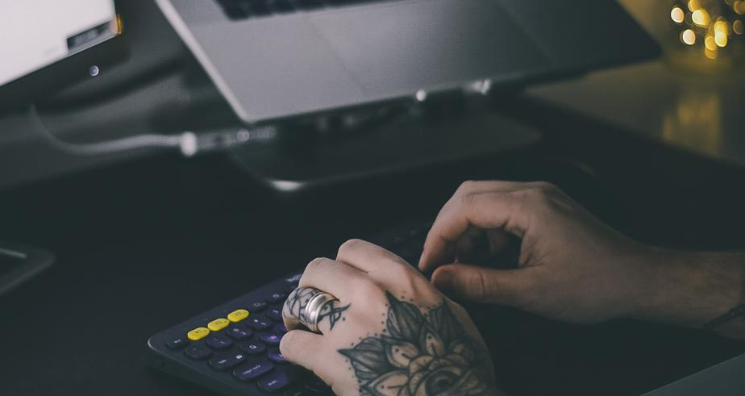

# 업데이트

- 다른 좋은 접근이 많아서 개발을 중지하였습니다.

### 한줄요약

1. 포스트나 발표자료에서 함수를 설명할 일이 많아서 `usehelp`라는 패키지를 만들었습니다.

저는 R 언어를 매우 사랑합니다. 이미 문법이 익숙해서, 다른 걸 사용하는게 매우 불편하죠. 이 블로그도 blogdown 패키지를 이용하고 있고, 발표자료는 xaringan으로 만들어 공유합니다. 포스트를 작성할 때 마다 대문 이미지를 계속 넣어왔는데요. `img` 태그를 쓰다가 결국, htmltools로 바꿨습니다. 아주 마음이 편하네요. ㅎㅎㅎ 잠시 딴길로 샜는데, 어쩄든 포스트나 발표자료를 R로 만들다 보니, 함수 설명할 일이 매우 많습니다.

매번 제가 직접 작성하고 있었는데… 생각해보니 설명서에 제목이며, 설명이며 다 있는 겁니다! 그래서 그 텍스트를 가져와서 출력해주는 패키지를 생각해보게 되었습니다.

### usehelp

당장 가볍게 만들다보니, 설명서의 텍스트를 R 객체로 가져오는 선에서 끝나고 있습니다. 이제 시작인 셈인데요. github 버전만 있어서 우선 `remotes::install_github()` 함수로 설치해야 합니다.

```r
remotes::install_github("mrchypark/usehelp")
```

그럼 이제 사용해 봅시다.

```r
library(usehelp)
get_help("usehelp","get_help")
```

```
{html_document}
<html xmlns="http://www.w3.org/1999/xhtml">
[1] <head>\n<title>R: get help</title>\n<meta http-equiv="Content-T ...
[2] <body>\n\n<table width="100%" summary="page for get_help"><tr>\ ...
```

```r
get_help("usehelp","get_help") %>%
  get_title()
```

```
[1] "get help"
```

그래서 필요한 글자를 가져오는 함수들은 전부 rvest를 덮어서 만들었습니다. 아직은 `title`과 `description`, `usage` 만 있지만 차츰 추가해 나가겠습니다.

### 향후 계획

우선 포스트와 발표자료에 예쁘게 사용하기 위해 `html` 출력을 추가할 계획입니다. `help` 클래스의 콘솔 출력도 조정해야 할 것 같구요. 마지막으로 가능하다면 번역기를 붙여서 한글자료 만들 때 어설픈 채로라도 사용할 수 있게 조정해볼 계획입니다.

마지막은 정말 희망사항이네요 ㅎㅎ

여기까지 usehelp 패키지 소개였습니다. 아직 사용할 수준은 아니지만, 사용하시게 되면 이슈나 PR 대환영입니다. 콘솔 출력과 `html` 형태 삽입만 마무리되면 cran에 등록할 계획입니다.

감사합니다.

Comment on this article Share: